# ARIMAX for Regression model 2

Author

Dr. Purna Gamage

# Regression Model 2

## Step 1: What is your model? or model variables?

(DA) Job openings vs. FEDFUNDS/PPI (Information)/CPE

## Step 2: load the data

**Here, make sure you re-arrange the data so that all the data has a common time-period and has a common time frequency**

#### Processing the Data

```r
# Load necessary packages
library(dplyr)
library(lubridate)
library(knitr)

# Set folder path
data_path <- "DA_Jobs_vs_Econ"

# Load the datasets
fedfunds <- read.csv(file.path(data_path, "FEDFUNDS.csv"))
indeed_da <- read.csv(file.path(data_path, "indeed_data_analysis_job_postings.csv"))
pce <- read.csv(file.path(data_path, "PCE.csv"))
ppi_info <- read.csv(file.path(data_path, "PPI_Information.csv"))

# Convert date columns to Date
fedfunds[, 1] <- as.Date(fedfunds[, 1])
pce[, 1] <- as.Date(pce[, 1])
ppi_info[, 1] <- as.Date(ppi_info[, 1])

# Clean Indeed dataset separately
indeed_da$dateString <- as.Date(indeed_da$dateString)

# Keep only date and value columns
fedfunds <- fedfunds[, 1:2]
pce <- pce[, 1:2]
ppi_info <- ppi_info[, 1:2]

indeed_da <- indeed_da %>%
  filter(
    countryCode == "US",
    sectorName == "Data & Analytics",
    postingType == "TOTAL"
  ) %>%
  select(dateString, value)

# Rename columns
colnames(fedfunds) <- c("Date", "FedFundsRate")
colnames(indeed_da) <- c("Date", "DataAnalysisJobPostings")
colnames(pce) <- c("Date", "PCE")
colnames(ppi_info) <- c("Date", "PPIInformation")

# Function to convert any dataset to monthly data
to_monthly <- function(df) {
  df %>%
    mutate(Date = floor_date(Date, unit = "month")) %>%
    group_by(Date) %>%
    summarise(
      across(
        .cols = where(is.numeric),
        .fns = ~ mean(.x, na.rm = TRUE)
      ),
      .groups = "drop"
    )
}

# Convert all datasets to monthly frequency
fedfunds_m <- to_monthly(fedfunds)
indeed_da_m <- to_monthly(indeed_da)
pce_m <- to_monthly(pce)
ppi_info_m <- to_monthly(ppi_info)

# Merge monthly datasets using only the common time period
merged_data <- Reduce(
  function(x, y) merge(x, y, by = "Date", all = FALSE),
  list(
    indeed_da_m,
    fedfunds_m,
    pce_m,
    ppi_info_m
  )
)

# Sort by Date
merged_data <- merged_data %>%
  arrange(Date)

# Remove any remaining missing values
merged_data <- merged_data %>%
  filter(if_all(-Date, ~ !is.na(.x)))

# Display common time period
cat(
  "Common monthly time period:",
  as.character(min(merged_data$Date)),
  "to",
  as.character(max(merged_data$Date)),
  "\n"
)
```

```
Common monthly time period: 2020-02-01 to 2026-05-01
```

```r
# Display number of monthly observations
cat("Number of monthly observations:", nrow(merged_data), "\n")
```

```
Number of monthly observations: 76
```

```r
# Display preview
kable(
  head(merged_data),
  caption = "Merged Monthly Dataset: Data Analysis Job Postings, Fed Funds Rate, PCE, and PPI Information"
)
```

Merged Monthly Dataset: Data Analysis Job Postings, Fed Funds Rate, PCE, and PPI Information

| Date | DataAnalysisJobPostings | FedFundsRate | PCE | PPIInformation |
| --- | --- | --- | --- | --- |
| 2020-02-01 | 99.84172 | 1.58 | 14828.1 | 104.3 |
| 2020-03-01 | 96.43355 | 0.65 | 13812.8 | 104.6 |
| 2020-04-01 | 69.63333 | 0.05 | 12249.2 | 104.5 |
| 2020-05-01 | 57.72194 | 0.05 | 13281.5 | 103.8 |
| 2020-06-01 | 56.88433 | 0.08 | 14049.2 | 103.8 |
| 2020-07-01 | 60.36871 | 0.09 | 14307.2 | 104.1 |

```r
# Assign final dataset
df <- merged_data
```

#### Visualizing all the variables together

to see the trends over time together

```r
# Load plotly
library(plotly)

# Use the merged monthly dataset
df <- merged_data

# Create individual plots for each variable with y-axis labels

p1 <- plot_ly(
  df,
  x = ~Date,
  y = ~DataAnalysisJobPostings,
  type = "scatter",
  mode = "lines",
  name = "Data Analysis Job Postings"
) %>%
  layout(yaxis = list(title = "Job Postings Index"))

p2 <- plot_ly(
  df,
  x = ~Date,
  y = ~FedFundsRate,
  type = "scatter",
  mode = "lines",
  name = "Federal Funds Rate"
) %>%
  layout(yaxis = list(title = "Rate"))

p3 <- plot_ly(
  df,
  x = ~Date,
  y = ~PCE,
  type = "scatter",
  mode = "lines",
  name = "PCE"
) %>%
  layout(yaxis = list(title = "PCE"))

p4 <- plot_ly(
  df,
  x = ~Date,
  y = ~PPIInformation,
  type = "scatter",
  mode = "lines",
  name = "PPI Information"
) %>%
  layout(yaxis = list(title = "PPI"))

# Combine the individual plots into one figure
final_plot <- subplot(
  p1, p2, p3, p4,
  nrows = 4,
  shareX = TRUE,
  titleX = TRUE
) %>%
  layout(
    title = "Monthly Time Series of Data Analysis Jobs, Federal Funds Rate, PCE, and PPI Information",
    yaxis = list(title = "Job Postings Index"),
    yaxis2 = list(title = "Rate"),
    yaxis3 = list(title = "PCE"),
    yaxis4 = list(title = "PPI"),
    xaxis = list(title = "Year"),
    showlegend = FALSE
  )

final_plot
```

[interactive chart not shown]

## Step 3: Convert to a ts() object

```r
# Load necessary packages
library(forecast)
library(lubridate)

# Use merged monthly dataset
df <- merged_data

# Make sure data are sorted by Date
df <- df[order(df$Date), ]

# Remove rows with missing values
df <- na.omit(df)

# Get start year and month from the first date
start_year <- year(min(df$Date))
start_month <- month(min(df$Date))

# Convert to time series object
# Monthly data: frequency = 12
df.ts <- ts(
  df[, -1],
  start = c(start_year, start_month),
  frequency = 12
)
```

## Step 5: EDA

Understand the correlation structure

### Lag Plots

```r
# Load necessary packages
library(forecast)
library(plotly)
library(ggplot2)
library(lubridate)

# Make sure df is sorted by Date
df <- df[order(df$Date), ]

# Remove missing values
df <- na.omit(df)

# Get start year and month from your actual dataset
start_year <- year(min(df$Date))
start_month <- month(min(df$Date))

# Variables used in the current models
variables <- c(
  "DataAnalysisJobPostings",
  "FedFundsRate",
  "PCE",
  "PPIInformation"
)

# Cleaner names for plot titles and axis labels
variable_labels <- c(
  DataAnalysisJobPostings = "Data Analysis Job Postings",
  FedFundsRate = "Federal Funds Rate",
  PCE = "PCE",
  PPIInformation = "PPI Information"
)

# Function to create lag plot for one variable
create_lag_plot <- function(var_name, lags = 12) {

  ts_var <- ts(
    df[[var_name]],
    start = c(start_year, start_month),
    frequency = 12
  )

  p <- gglagplot(
    ts_var,
    do.lines = FALSE,
    lags = lags
  ) +
    ggtitle(paste("Lag Plots for", variable_labels[var_name])) +
    xlab(paste("Lagged", variable_labels[var_name])) +
    ylab(paste("Current", variable_labels[var_name])) +
    theme_minimal()

  ggplotly(p)
}

# Create lag plots
lag_plot_job_postings <- create_lag_plot("DataAnalysisJobPostings")
lag_plot_fedfunds <- create_lag_plot("FedFundsRate")
lag_plot_pce <- create_lag_plot("PCE")
lag_plot_ppi <- create_lag_plot("PPIInformation")

# Display lag plots
lag_plot_job_postings
```

[interactive chart not shown]

```r
lag_plot_fedfunds
```

[interactive chart not shown]

```r
lag_plot_pce
```

[interactive chart not shown]

```r
lag_plot_ppi
```

[interactive chart not shown]

### ACF Plots

```r
# Load necessary packages
library(forecast)
library(plotly)
library(ggplot2)
library(lubridate)
library(htmltools)

# Make sure df is sorted by Date
df <- df[order(df$Date), ]

# Remove missing values
df <- na.omit(df)

# Get start year and month from your actual dataset
start_year <- year(min(df$Date))
start_month <- month(min(df$Date))

# Variables used in the current monthly model
variables <- c(
  "DataAnalysisJobPostings",
  "FedFundsRate",
  "PCE",
  "PPIInformation"
)

# Cleaner names for plot titles and axis labels
variable_labels <- c(
  DataAnalysisJobPostings = "Data Analysis Job Postings",
  FedFundsRate = "Federal Funds Rate",
  PCE = "PCE",
  PPIInformation = "PPI Information"
)

# Function to create ACF plot for one variable
create_acf_plot <- function(var_name, lag_max = 30) {

  ts_var <- ts(
    df[[var_name]],
    start = c(start_year, start_month),
    frequency = 12
  )

  p <- ggAcf(
    ts_var,
    lag.max = lag_max
  ) +
    ggtitle(paste("ACF Plot for", variable_labels[var_name])) +
    xlab("Lag in Months") +
    ylab("Autocorrelation")

  ggplotly(p)
}

# Create ACF plots
acf_plot_job_postings <- create_acf_plot("DataAnalysisJobPostings")
acf_plot_fedfunds <- create_acf_plot("FedFundsRate")
acf_plot_pce <- create_acf_plot("PCE")
acf_plot_ppi <- create_acf_plot("PPIInformation")

# Display ACF plots
acf_plot_job_postings
```

[interactive chart not shown]

```r
acf_plot_fedfunds
```

[interactive chart not shown]

```r
acf_plot_pce
```

[interactive chart not shown]

```r
acf_plot_ppi
```

[interactive chart not shown]

### Stationarity

```r
# Load necessary package
library(tseries)
library(dplyr)
library(knitr)
library(kableExtra)
library(lubridate)

# Make sure df is sorted by Date
df <- df[order(df$Date), ]

# Remove missing values
df <- na.omit(df)

# Get start year and month from your actual dataset
start_year <- year(min(df$Date))
start_month <- month(min(df$Date))

# Variables used in the current monthly model
variables <- c(
  "DataAnalysisJobPostings",
  "FedFundsRate",
  "PCE",
  "PPIInformation"
)

# Cleaner names
variable_labels <- c(
  DataAnalysisJobPostings = "Data Analysis Job Postings",
  FedFundsRate = "Federal Funds Rate",
  PCE = "PCE",
  PPIInformation = "PPI Information"
)

# Function to run ADF test for one variable
run_adf_test <- function(var_name) {

  ts_var <- ts(
    df[[var_name]],
    start = c(start_year, start_month),
    frequency = 12
  )

  adf_result <- adf.test(ts_var)

  data.frame(
    Variable = variable_labels[var_name],
    ADF_Statistic = as.numeric(adf_result$statistic),
    Lag_Order = as.numeric(adf_result$parameter),
    P_Value = adf_result$p.value,
    Conclusion = ifelse(
      adf_result$p.value < 0.05,
      "Stationary",
      "Non-stationary"
    )
  )
}

# Run ADF test for all variables
adf_results <- do.call(
  rbind,
  lapply(variables, run_adf_test)
)

# Display results
knitr::kable(
  adf_results,
  digits = 4,
  caption = "ADF Test Results for Monthly Variables"
) |>
  kableExtra::kable_styling(
    full_width = FALSE,
    position = "center",
    bootstrap_options = c("striped", "hover", "condensed")
  )
```

ADF Test Results for Monthly Variables

|  | Variable | ADF_Statistic | Lag_Order | P_Value | Conclusion |
| --- | --- | --- | --- | --- | --- |
| DataAnalysisJobPostings | Data Analysis Job Postings | -4.5443 | 4 | 0.0100 | Stationary |
| FedFundsRate | Federal Funds Rate | -1.8527 | 4 | 0.6356 | Non-stationary |
| PCE | PCE | -2.8296 | 4 | 0.2369 | Non-stationary |
| PPIInformation | PPI Information | -2.2205 | 4 | 0.4855 | Non-stationary |

if p-value < 0.05 -> reject unit root -> stationary

if p-value >= 0.05 -> fail to reject unit root -> non-stationary

## Step 6: Fitting the ARIMAX model using ’auto.arima()`

```r
# Define the dependent variable
# Modeling Data Analysis job postings
y <- df.ts[, "DataAnalysisJobPostings"]

# Define external regressors
# Fed Funds Rate, PCE, and PPI Information
xreg <- df.ts[, c(
  "FedFundsRate",
  "PCE",
  "PPIInformation"
)]

# Fit the ARIMA model with external regressors
fit <- auto.arima(y, xreg = xreg)

# Display model summary
summary(fit)
```

```
Series: y
Regression with ARIMA(2,0,3)(1,0,0)[12] errors

Coefficients:
         ar1      ar2      ma1      ma2     ma3    sar1  FedFundsRate     PCE
      1.9038  -0.9261  -0.3054  -0.3652  0.4241  0.3382       -6.2969  0.0063
s.e.  0.0612   0.0611   0.1463   0.1370  0.1580  0.1623        3.7001  0.0014
      PPIInformation
              0.0008
s.e.          0.2575

sigma^2 = 13.63:  log likelihood = -206.54
AIC=433.07   AICc=436.46   BIC=456.38

Training set error measures:
                     ME     RMSE      MAE        MPE     MAPE       MASE
Training set -0.1122304 3.466978 2.459962 -0.3069704 2.921699 0.05593549
                   ACF1
Training set 0.06480216
```

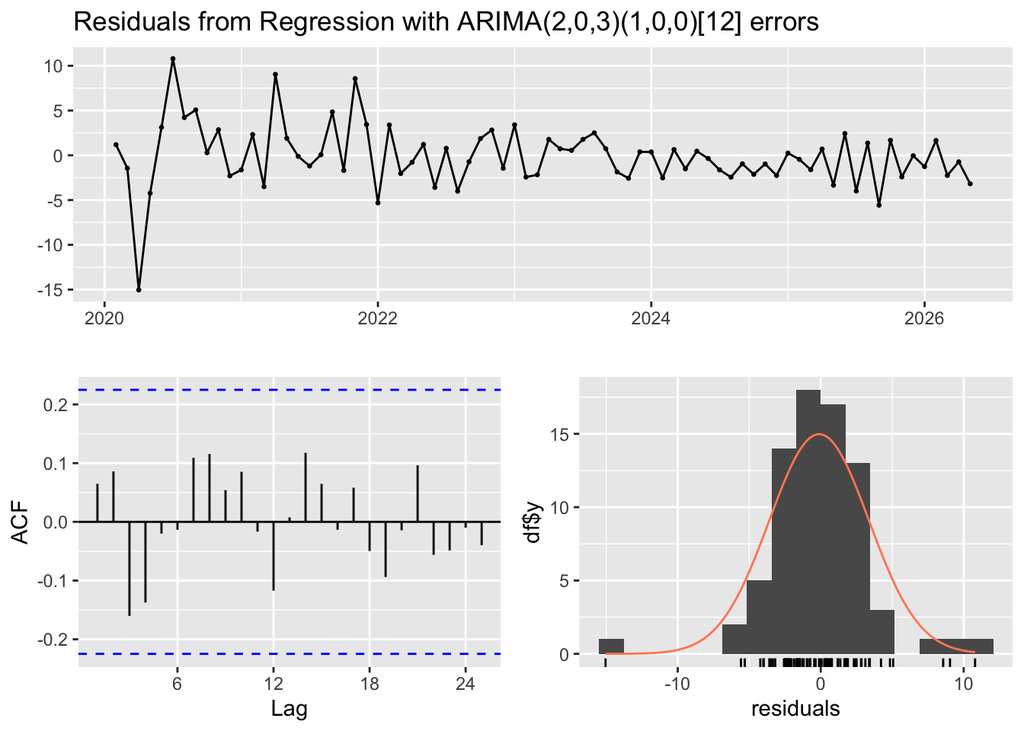

```
    Ljung-Box test

data:  Residuals from Regression with ARIMA(2,0,3)(1,0,0)[12] errors
Q* = 10.727, df = 9, p-value = 0.2949

Model df: 6.   Total lags used: 15
```

```r
# Model diagnostics
checkresiduals(fit)
```

## Step 7: Fitting the model manually

### Regression + ARIMA(residuals of the Regression)

```r
# Fit a linear regression model
model <- lm(
  DataAnalysisJobPostings ~ FedFundsRate + PCE + PPIInformation,
  data = df
)

# Display model summary
summary(model)
```

```
Call:
lm(formula = DataAnalysisJobPostings ~ FedFundsRate + PCE + PPIInformation,
    data = df)

Residuals:
    Min      1Q  Median      3Q     Max
-40.247 -19.529  -0.008  18.283  66.464

Coefficients:
                 Estimate Std. Error t value Pr(>|t|)
(Intercept)     1.536e+03  1.309e+02  11.735  < 2e-16 ***
FedFundsRate   -1.314e+01  2.075e+00  -6.332 1.84e-08 ***
PCE             4.337e-02  3.892e-03  11.145  < 2e-16 ***
PPIInformation -1.975e+01  1.712e+00 -11.536  < 2e-16 ***
---
Signif. codes:  0 '***' 0.001 '**' 0.01 '*' 0.05 '.' 0.1 ' ' 1

Residual standard error: 23.29 on 72 degrees of freedom
Multiple R-squared:  0.7376,    Adjusted R-squared:  0.7266
F-statistic: 67.46 on 3 and 72 DF,  p-value: < 2.2e-16
```

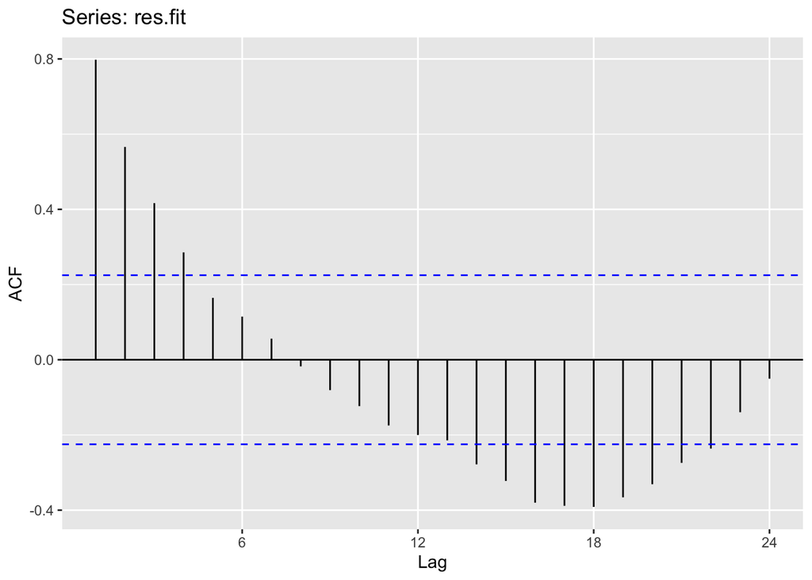

```r
# Get start year and month from the common monthly dataset
start_year <- year(min(df$Date))
start_month <- month(min(df$Date))

# Extract residuals from the model
res.fit <- ts(
  residuals(model),
  start = c(start_year, start_month),
  frequency = 12
)

ggAcf(res.fit)
```

## Step 8: Model Search for the residuals

1. This is just checking:

```r
auto.arima(res.fit)
```

```
Series: res.fit
ARIMA(1,0,1) with zero mean

Coefficients:
         ar1     ma1
      0.6975  0.2939
s.e.  0.0987  0.1363

sigma^2 = 178:  log likelihood = -304.31
AIC=614.61   AICc=614.95   BIC=621.6
```

### 2. Manual Search

**Manual parameter search through differencing ordinarily and seasonally:**

#### Apply First-Order Differencing only

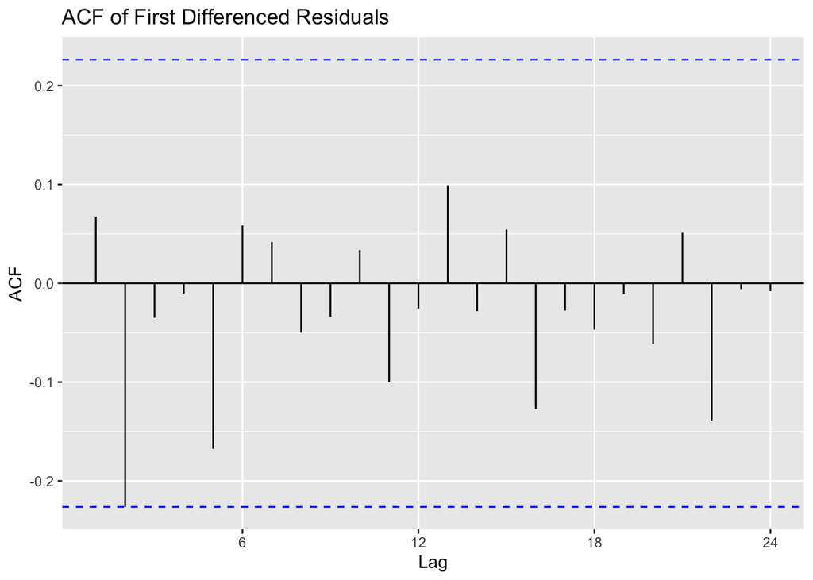

```r
#| code-fold: true

###### Apply First-Order Differencing ######

first_diff <- diff(res.fit)

ggAcf(first_diff)+

  ggtitle("ACF of First Differenced Residuals")
```

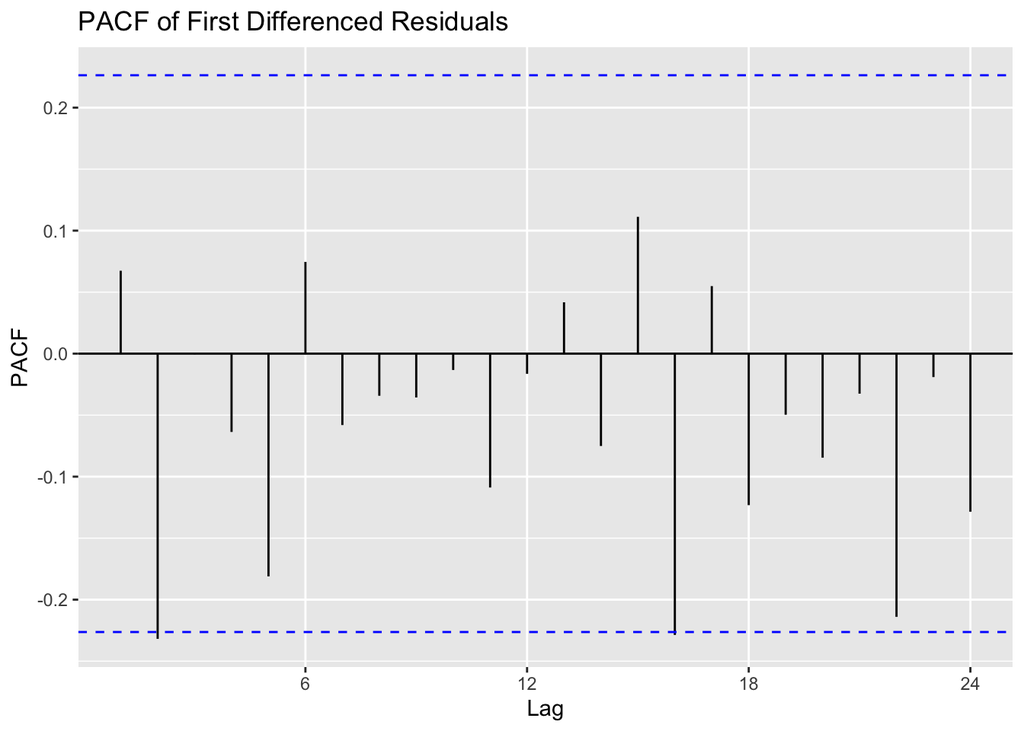

```r
ggPacf(first_diff) +

  ggtitle("PACF of First Differenced Residuals")
```

it is apparent that no ordinary differencing is needed, so d=0 can be a possible candidate.

##### Check the ACF of the residuals

I’m doing this step since it shows above d=0, but id d=1, you don’t need to check this.

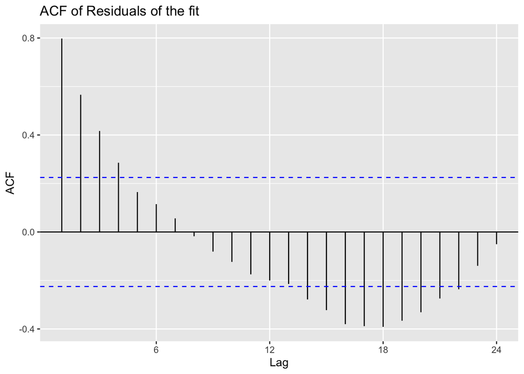

```r
ggAcf(res.fit)+

  ggtitle("ACF of Residuals of the fit")
```

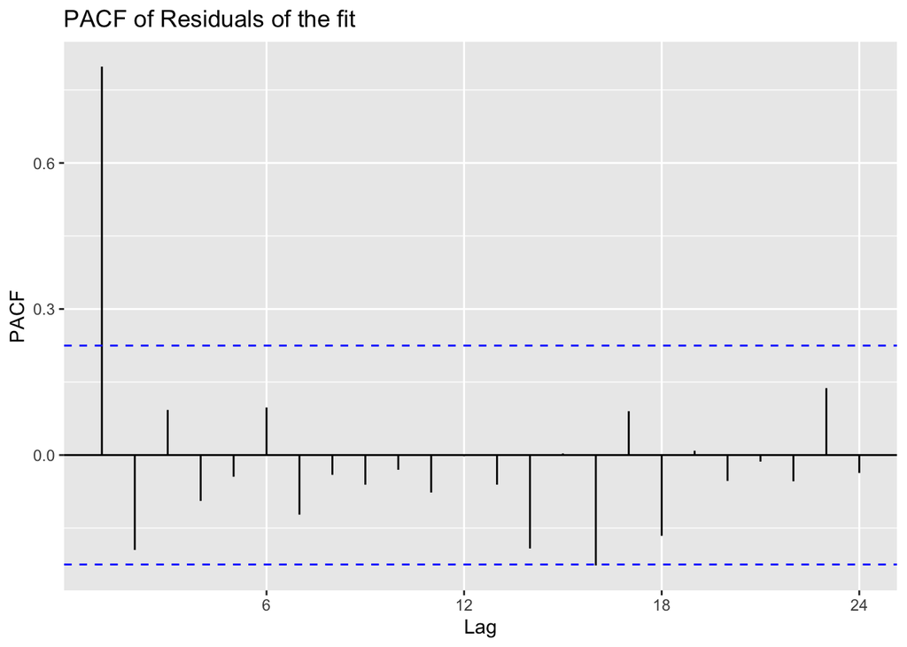

```r
ggPacf(res.fit) +

  ggtitle("PACF of Residuals of the fit")
```

from ACF plot -> q= 1,2,3,4 and from PACF plot -> p=1

#### Apply Seasonal Differencing only

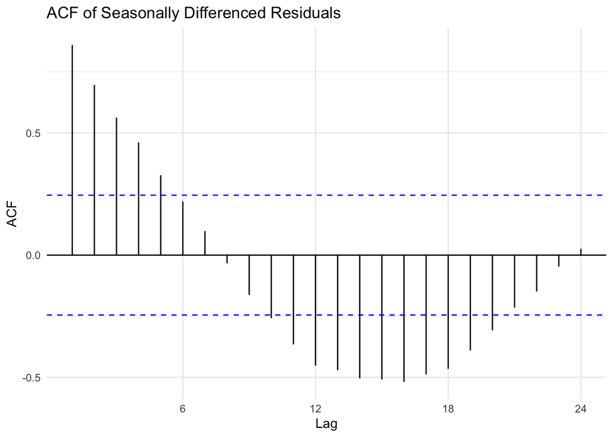

```r
###### Apply Seasonal Differencing (Lag = 12) only ######

seasonal_diff <- diff(res.fit, lag = 12)

###### Plot ACF and PACF for the Differenced Series ######

p3 <- ggAcf(seasonal_diff) +

  ggtitle("ACF of Seasonally Differenced Residuals") +

  theme_minimal()

p4 <- ggPacf(seasonal_diff) +

  ggtitle("PACF of Seasonally Differenced Residuals") +

  theme_minimal()

# Display plots
p3
```

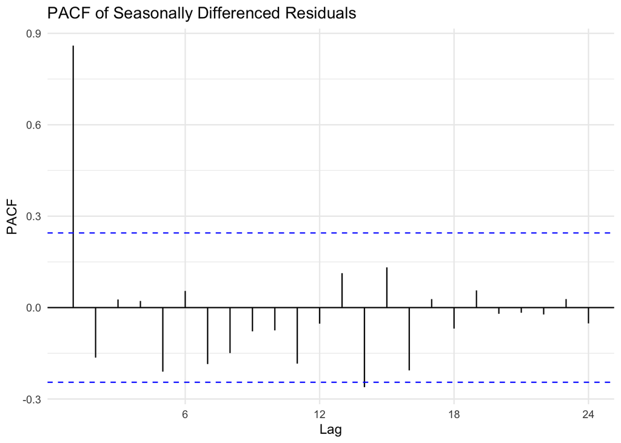

```r
p4
```

from PACF: P=1, and from ACF: Q=1, since we seasonaly differenced once: D=1

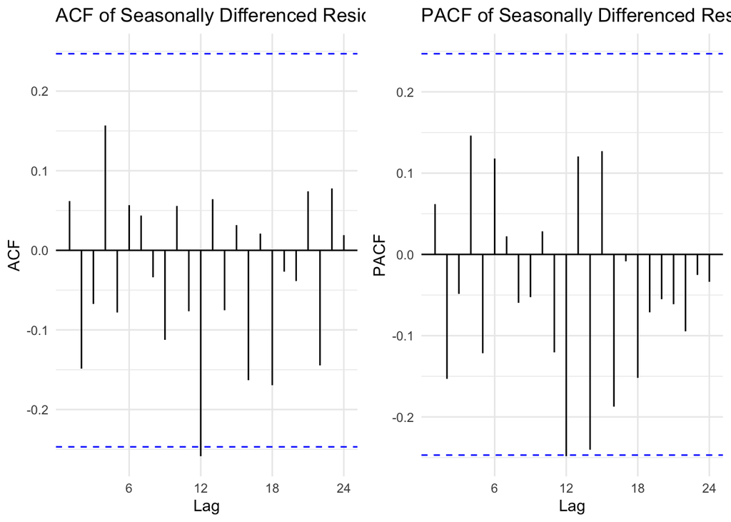

```r
###### Apply Seasonal Differencing (Lag = 12) on Top of First-Order Differencing ######

seasonal_diff <- diff(first_diff, lag = 12)

###### Plot ACF and PACF for the Differenced Series ######

p1 <- ggAcf(seasonal_diff) +

  ggtitle("ACF of Seasonally Differenced Residuals") +

  theme_minimal()

p2 <- ggPacf(seasonal_diff) +

  ggtitle("PACF of Seasonally Differenced Residuals") +

  theme_minimal()

# Display plots

gridExtra::grid.arrange(p1, p2, ncol = 2)
```

Here d=1, D=1, P=1, Q=1

## Step 9: Parameter tuning

**Let’s run through a parameter search using the above selected parameters in the ARIMA model:**

#### This is in case you DON’T have seasonality.

```r
# Load necessary libraries
library(knitr)
library(kableExtra)


# Define parameter ranges
p_range <- 1:4
d_range <- 0:1
q_range <- 1:1  #

# Calculate total combinations
n_combinations <- length(p_range) * length(d_range) * length(q_range)

# Create an empty matrix to store results
results_matrix <- matrix(NA, nrow = n_combinations, ncol = 6)

# Initialize index for matrix row
i <- 1

# Loop through combinations of ARIMA model parameters
for (d in d_range) {
  for (p in p_range) {
    for (q in q_range)

    # Fit ARIMA model with specified (p,d,q)
    model <- Arima(res.fit, order = c(p, d, q), include.drift = TRUE)

    # Store model parameters and AIC/BIC/AICc values in matrix
    results_matrix[i, ] <- c(p, d, q, model$aic, model$bic, model$aicc)

    # Increment row index
    i <- i + 1
  }
}

# Convert matrix to data frame
results_df <- as.data.frame(results_matrix)
colnames(results_df) <- c("p", "d", "q", "AIC", "BIC", "AICc")

# Load libraries
library(dplyr)
library(knitr)
library(kableExtra)

# Create table of top 10 models based on AIC
top_results_df <- results_df |>
  arrange(AIC) |>
  head(10)

# Find the row with the lowest AIC in the top 10 table
highlight_row <- which.min(top_results_df$AIC)

# Generate kable table with highlighting for the row with the lowest AIC
knitr::kable(
  top_results_df,
  align = "c",
  digits = 3,
  caption = "Top 10 ARIMA Models Based on AIC"
) |>
  kable_styling(
    full_width = FALSE,
    position = "center"
  ) |>
  row_spec(
    highlight_row,
    bold = TRUE,
    background = "#FFFF99"
  )
```

Top 10 ARIMA Models Based on AIC

| p | d | q | AIC | BIC | AICc |
| --- | --- | --- | --- | --- | --- |
| 3 | 1 | 1 | 614.546 | 628.451 | 615.781 |
| 4 | 1 | 1 | 615.924 | 632.147 | 617.596 |
| 2 | 1 | 1 | 616.466 | 628.054 | 617.336 |
| 1 | 1 | 1 | 617.620 | 626.890 | 618.191 |
| 4 | 0 | 1 | 617.869 | 636.515 | 620.019 |
| 1 | 0 | 1 | 618.535 | 630.189 | 619.393 |
| 2 | 0 | 1 | 620.413 | 634.397 | 621.630 |
| 3 | 0 | 1 | 622.169 | 638.484 | 623.816 |

#### This is when you have seasonality.

## SARIMA model

```r
# ------------------------------------------------------------
# Load libraries
# ------------------------------------------------------------

library(forecast)
library(dplyr)

# ------------------------------------------------------------
# Check time series object
# ------------------------------------------------------------

#frequency(ts_unemployment)
#length(ts_unemployment)
#sum(is.na(ts_unemployment))

# ------------------------------------------------------------
# SARIMA Model Comparison Function
# ------------------------------------------------------------

SARIMA.c <- function(p1, p2, q1, q2, P1, P2, Q1, Q2, data) {

  # Differencing orders and seasonal period
  d <- 0
  D <- 1
  s <- 12

  # Store results
  results <- list()
  i <- 1

  # Iterate over parameter ranges
  for (p in p1:p2) {
    for (q in q1:q2) {
      for (P in P1:P2) {
        for (Q in Q1:Q2) {

          # Avoid overly complex models
          if (p + d + q + P + D + Q <= 10) {

            model <- tryCatch(
              {
                forecast::Arima(
                  data,
                  order = c(p, d, q),
                  seasonal = list(order = c(P, D, Q), period = s)
                )
              },
              error = function(e) {
                message(
                  "Model failed: ARIMA(",
                  p, ",", d, ",", q, ") x (",
                  P, ",", D, ",", Q, ")[", s, "] : ",
                  e$message
                )
                return(NULL)
              }
            )

            if (!is.null(model)) {
              results[[i]] <- data.frame(
                p = p,
                d = d,
                q = q,
                P = P,
                D = D,
                Q = Q,
                AIC = model$aic,
                BIC = model$bic,
                AICc = model$aicc
              )

              i <- i + 1
            }
          }
        }
      }
    }
  }

  # If no models worked, stop with clear message
  if (length(results) == 0) {
    stop("No SARIMA models were successfully fitted. Check the error messages above.")
  }

  # Combine results
  results_df <- bind_rows(results)

  return(results_df)
}

# ------------------------------------------------------------
# Run SARIMA Model Comparison
# ------------------------------------------------------------

#q= 1,2,3,4 and p=1, D=1, Q=1, P=1
output <- SARIMA.c(
  p1 = 0, p2 = 1,
  q1 = 1, q2 = 4,
  P1 = 0, P2 = 1,
  Q1 = 0, Q2 = 1,
  data = res.fit
)


# Optional: show top models
results_top<-output |>
  arrange(AIC) |>
  head(10)

highlight_row <- which.min(results_top$AIC)

knitr::kable(
  results_top,
  align = "c",
  digits = 3,
  caption = "Top 10 SARIMA Models Based on AIC"
) %>%
  kable_styling(
    full_width = FALSE,
    position = "center"
  ) %>%
  row_spec(
    highlight_row,
    bold = TRUE,
    background = "#FFFF99"
  )
```

Top 10 SARIMA Models Based on AIC

| p | d | q | P | D | Q | AIC | BIC | AICc |
| --- | --- | --- | --- | --- | --- | --- | --- | --- |
| 1 | 0 | 1 | 0 | 1 | 1 | 544.149 | 552.784 | 544.827 |
| 1 | 0 | 1 | 1 | 1 | 1 | 545.894 | 556.688 | 546.928 |
| 1 | 0 | 1 | 1 | 1 | 0 | 546.106 | 554.742 | 546.784 |
| 1 | 0 | 2 | 0 | 1 | 1 | 546.121 | 556.915 | 547.155 |
| 1 | 0 | 4 | 0 | 1 | 1 | 547.083 | 562.195 | 549.083 |
| 1 | 0 | 3 | 0 | 1 | 1 | 547.301 | 560.254 | 548.775 |
| 1 | 0 | 2 | 1 | 1 | 1 | 547.820 | 560.774 | 549.294 |
| 1 | 0 | 2 | 1 | 1 | 0 | 548.046 | 558.841 | 549.081 |
| 1 | 0 | 4 | 1 | 1 | 0 | 548.530 | 563.642 | 550.530 |
| 0 | 0 | 4 | 0 | 1 | 1 | 548.696 | 561.650 | 550.170 |

```r
# ------------------------------------------------------------
# Identify Best Models
# ------------------------------------------------------------

best_models <- bind_rows(
  "Best by AIC" = output |> slice_min(AIC, n = 1, with_ties = FALSE),
  "Best by BIC" = output |> slice_min(BIC, n = 1, with_ties = FALSE),
  .id = "Selection_Criterion"
)

knitr::kable(
  best_models,
  align = "c",
  digits = 3,
  caption = "Best SARIMA Models Based on AIC and BIC"
) |>
  kable_styling(
    full_width = FALSE,
    position = "center",
    bootstrap_options = c("striped", "hover", "condensed")
  )
```

Best SARIMA Models Based on AIC and BIC

| Selection_Criterion | p | d | q | P | D | Q | AIC | BIC | AICc |
| --- | --- | --- | --- | --- | --- | --- | --- | --- | --- |
| Best by AIC | 1 | 0 | 1 | 0 | 1 | 1 | 544.149 | 552.784 | 544.827 |
| Best by BIC | 1 | 0 | 1 | 0 | 1 | 1 | 544.149 | 552.784 | 544.827 |

## Step 10: Write down the Possible Models

ARIMA(1,0,1)

ARIMA(3,1,1)

ARIMA(1,0,1)(0,1,1)12

## Step 11: Model Diagnostics

```r
# Load libraries
library(astsa)
library(forecast)
library(lubridate)
library(dplyr)
library(ggplot2)
library(knitr)
library(kableExtra)

# Make sure res.fit is a monthly time series
# This assumes res.fit was already created from your model residuals
# frequency(res.fit) should be 12

frequency(res.fit)
```

```
[1] 12
```

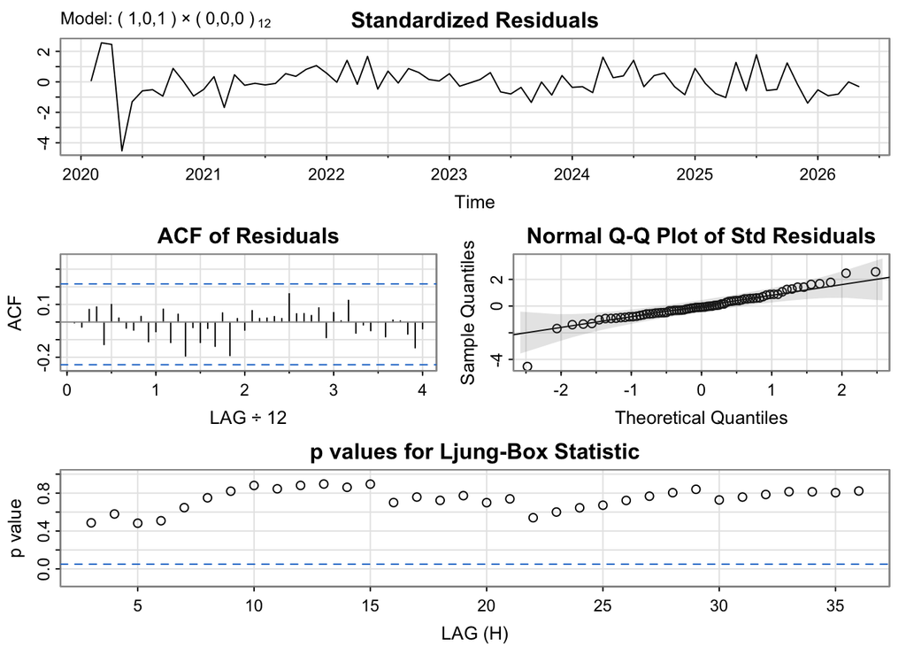

```r
# Set seed for reproducibility
set.seed(345)

###### Fit ARIMA(1,0,1) Model ######
model_1_output <- capture.output(
  sarima(res.fit, 1, 0, 1, 0, 0, 0, 12)
)
```

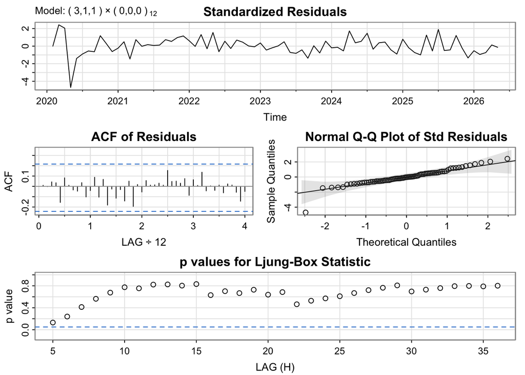

```r
###### Fit ARIMA(3,1,1) Model ######
model_2_output <- capture.output(
  sarima(res.fit, 3, 1, 1, 0, 0, 0, 12)
)
```

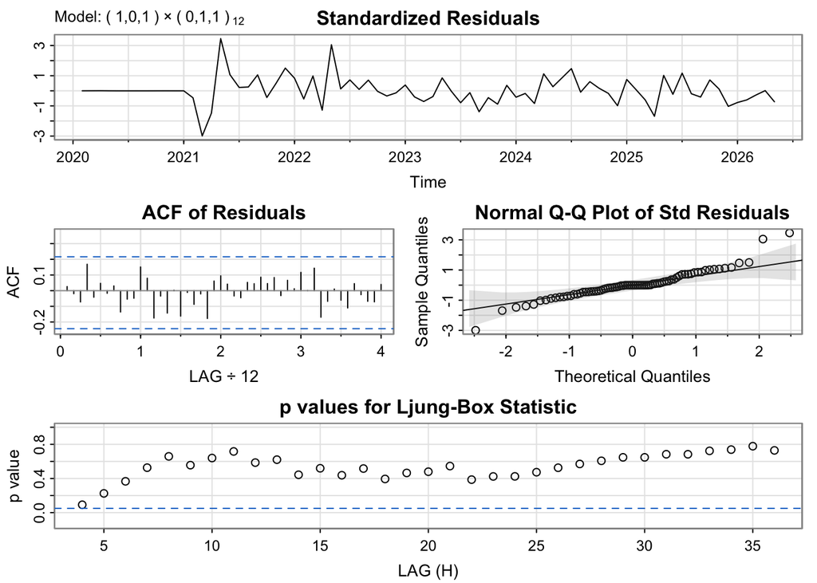

```r
###### Fit SARIMA(1,0,1)(0,1,1)[12] Model ######
model_3_output <- capture.output(
  sarima(res.fit, 1, 0, 1, 0, 1, 1, 12)
)
```

```r
###### Extract and Print Relevant Output ######
extract_model_output <- function(model_output, model_name) {

  start_line <- grep("Coefficients", model_output)

  if (length(start_line) == 0) {
    start_line <- 1
  }

  end_line <- length(model_output)

  cat("\n###", model_name, "###\n")
  cat(model_output[start_line:end_line], sep = "\n")
}

###### Print Model Outputs ######
extract_model_output(model_1_output, "ARIMA(1,0,1)")
```

```
### ARIMA(1,0,1) ###
Coefficients:
      Estimate     SE t.value p.value
ar1     0.6977 0.0987  7.0720  0.0000
ma1     0.2936 0.1363  2.1546  0.0345
xmean  -0.8658 6.2659 -0.1382  0.8905

sigma^2 estimated as 173.3057 on 73 degrees of freedom

AIC = 8.113066  AICc = 8.117452  BIC = 8.235736
```

```r
extract_model_output(model_2_output, "ARIMA(3,1,1)")
```

```
### ARIMA(3,1,1) ###
Coefficients:
         Estimate     SE  t.value p.value
ar1        0.9859 0.1169   8.4363  0.0000
ar2       -0.3062 0.1596  -1.9179  0.0592
ar3        0.1419 0.1296   1.0944  0.2775
ma1       -1.0000 0.0373 -26.8135  0.0000
constant  -0.1334 0.3444  -0.3874  0.6996

sigma^2 estimated as 175.2464 on 70 degrees of freedom

AIC = 8.193945  AICc = 8.205539  BIC = 8.379344
```

```r
extract_model_output(model_3_output, "SARIMA(1,0,1)(0,1,1)[12]")
```

```
### SARIMA(1,0,1)(0,1,1)[12] ###
Coefficients:
         Estimate     SE t.value p.value
ar1        0.7592 0.0966  7.8596  0.0000
ma1        0.2408 0.1442  1.6697  0.1002
sma1      -0.5759 0.1704 -3.3789  0.0013
constant  -0.0615 0.4388 -0.1401  0.8890

sigma^2 estimated as 231.5607 on 60 degrees of freedom

AIC = 8.533267  AICc = 8.54386  BIC = 8.701929
```

#### Change these interpretations accordingly:

The **Residual Plot** shows nearly consistent fluctuation around zero, suggesting that the residuals are nearly stationary with a constant mean and finite variance over time.

The **Autocorrelation Function (ACF)** of the residuals reveals no significant autocorrelations indicating a good model.

The **Q-Q Plot** indicates that the residuals follow a near-normal distribution, with minor deviations at the tails, which is typical in time series data.

The **Ljung-Box Test** p-values remain mostly above the 0.05 significance level, implying a nearly good fit.

## Step 12: Model Equation

```r
# Define the dependent variable
# Modeling Data Analysis Job Postings
y <- df.ts[, "DataAnalysisJobPostings"]

# Define external regressors
# Fed Funds Rate, PCE, and PPI Information
xreg <- df.ts[, c(
  "FedFundsRate",
  "PCE",
  "PPIInformation"
)]


# Fit final ARIMAX model:
# ARIMA(1,0,1)(0,1,1)[12] with external regressors
fit <- Arima(
  y,
  order = c(1, 0, 1),
  seasonal = list(order = c(0, 1, 1), period = 12),
  xreg = xreg
)

# Display model summary
summary(fit)
```

```
Series: y
Regression with ARIMA(1,0,1)(0,1,1)[12] errors

Coefficients:
         ar1     ma1     sma1  FedFundsRate     PCE  PPIInformation
      0.9824  0.8091  -0.6881       -8.9769  0.0064         -0.8042
s.e.  0.0189  0.0748   0.2155        3.8464  0.0019          0.7033

sigma^2 = 25.14:  log likelihood = -196.68
AIC=407.36   AICc=409.36   BIC=422.47

Training set error measures:
                     ME     RMSE      MAE        MPE     MAPE       MASE
Training set -0.1428329 4.380482 3.025418 -0.3843959 3.087695 0.06879303
                  ACF1
Training set 0.2542806
```

# Final Forecasting

First, forecast individual exogenous variables using auto.arima() models.

```r
# Fit ARIMA model to each external regressor

# Federal Funds Rate
FedFunds_fit <- auto.arima(xreg[, "FedFundsRate"])
# summary(FedFunds_fit)
fFedFunds <- forecast(FedFunds_fit, h = 36)

# PCE
PCE_fit <- auto.arima(xreg[, "PCE"])
# summary(PCE_fit)
fPCE <- forecast(PCE_fit, h = 36)

# PPI Information
PPI_fit <- auto.arima(xreg[, "PPIInformation"])
# summary(PPI_fit)
fPPI <- forecast(PPI_fit, h = 36)

# Create future external regressor matrix using forecasted values
fxreg <- cbind(
  FedFundsRate = fFedFunds$mean,
  PCE = fPCE$mean,
  PPIInformation = fPPI$mean
)
```

using the forecast individual exogenous variables using auto.arima() models, we will forecast our y variable.

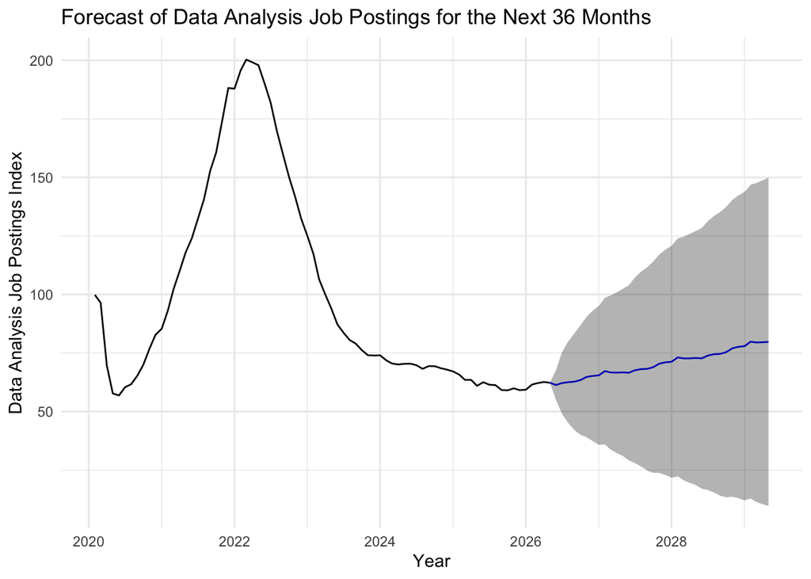

```r
# Forecast Data Analysis Job Postings using future external regressors
fcast <- forecast(
  fit,
  xreg = fxreg,
  h = 36
)

# Static forecast plot
autoplot(fcast) +
  ggtitle("Forecast of Data Analysis Job Postings for the Next 36 Months") +
  xlab("Year") +
  ylab("Data Analysis Job Postings Index") +
  theme_minimal()
```

```r
library(plotly)
library(lubridate)

# Create future monthly dates
future_dates <- seq(
  from = max(df$Date) %m+% months(1),
  by = "month",
  length.out = 36
)

# Create a data frame from the forecast object
fcast_df <- data.frame(
  Date = future_dates,
  Forecast = as.numeric(fcast$mean),
  Lower80 = as.numeric(fcast$lower[, 1]),
  Upper80 = as.numeric(fcast$upper[, 1]),
  Lower95 = as.numeric(fcast$lower[, 2]),
  Upper95 = as.numeric(fcast$upper[, 2])
)

# Convert the original series for plotting
orig_df <- data.frame(
  Date = df$Date,
  Actual = as.numeric(y)
)

# Plotly interactive plot
plot_ly() |>
  add_lines(
    data = orig_df,
    x = ~Date,
    y = ~Actual,
    name = "Actual"
  ) |>
  add_lines(
    data = fcast_df,
    x = ~Date,
    y = ~Forecast,
    name = "Forecast"
  ) |>
  add_ribbons(
    data = fcast_df,
    x = ~Date,
    ymin = ~Lower95,
    ymax = ~Upper95,
    name = "95% CI",
    opacity = 0.2,
    showlegend = FALSE
  ) |>
  add_ribbons(
    data = fcast_df,
    x = ~Date,
    ymin = ~Lower80,
    ymax = ~Upper80,
    name = "80% CI",
    opacity = 0.3,
    showlegend = FALSE
  ) |>
  layout(
    title = "Forecast of Data Analysis Job Postings for the Next 36 Months",
    xaxis = list(title = "Year"),
    yaxis = list(title = "Data Analysis Job Postings Index")
  )
```

[interactive chart not shown]